# CAS_nlme

HoxoMaxwell

2019-06-25

# 1 Introduction

In this notebook, we will do some experiments about Time Series Multilevel Models beyond the panel data.  
Here is a simple figure which shows the difference of the panel data and the multilevel data.

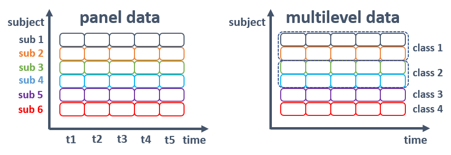

# 2 Libraries

```r
library(tidyverse)
library(CASdatasets)
library(nlme)
library(DT)
library(gridExtra)
library(caret)
```

# 3 Load Data

- In this notebook, we will use a dataset of automobile BIL claims (Frees & Wang, 2005) which is a long format data.

| Variable | Description |
| --- | --- |
| TOWNCODE | The index of Massachusetts towns |
| YEAR | The calendar year of the observation |
| AC | Average claims per unit of exposure |
| PCI | Per-capita income of the town |
| PPSM | Population per square mile of the town |

```r
data("usmassBI2")
dim(usmassBI2)
```

```
## [1] 174   5
```

```r
datatable(
  usmassBI2,
  options = list(pageLength = 10,
                 autoWidth = TRUE,
                 scrollX = TRUE,
                 columnDefs = list(list(width = '175px',
                                        targets = seq(1, dim(usmassBI2)[2])))),
  class = 'cell-border stripe'
  )
```

|  | TOWNCODE | YEAR | AC | PCI | PPSM |
| --- | --- | --- | --- | --- | --- |
| 1 | 10 | 1993 | 160.8522073 | 18134.04121 | 1475.551492 |
| 2 | 10 | 1994 | 158.3382074 | 18495.88323 | 1461.810971 |
| 3 | 10 | 1995 | 156.8098407 | 18778.28631 | 1488.991127 |
| 4 | 10 | 1996 | 168.9899151 | 18740.45693 | 1502.93224 |
| 5 | 10 | 1997 | 171.8229455 | 18809.62336 | 1534.425114 |
| 6 | 10 | 1998 | 153.7643528 | 19034.59306 | 1557.693735 |
| 7 | 11 | 1993 | 149.3873354 | 15597.55618 | 855.4349935 |
| 8 | 11 | 1994 | 137.5545733 | 15908.78582 | 877.2724568 |
| 9 | 11 | 1995 | 169.9164456 | 16151.68799 | 872.802372 |
| 10 | 11 | 1996 | 169.0598153 | 16119.14996 | 898.7801598 |

[output cut: 164 more lines]

# 4 Split Data into Train and Test

```r
usmassBI2$YEAR <- as.factor(usmassBI2$YEAR)
train <- usmassBI2 %>% filter(YEAR != 1998)
test <- usmassBI2 %>% filter(YEAR == 1998)
```

# 5 EDA

## 5.1 YEAR vs Average Claim

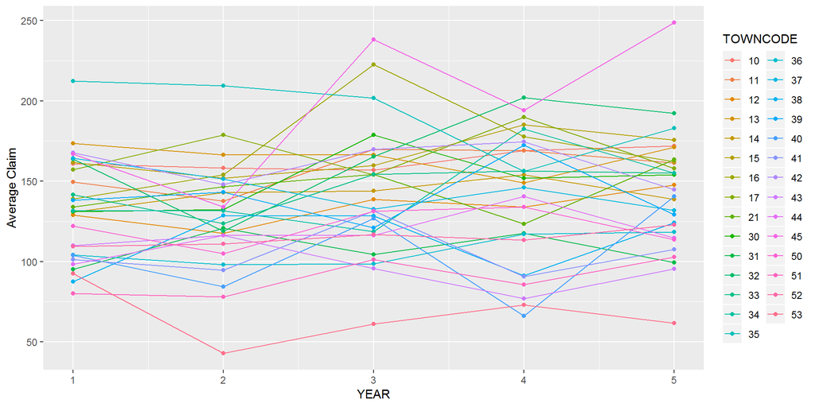

```r
train %>% select(YEAR, AC, TOWNCODE) %>%
  ggplot() +
  geom_line(mapping = aes(
    x = as.numeric(YEAR), y = AC, color = TOWNCODE)) +
  geom_point(mapping = aes(
    x = as.numeric(YEAR), y = AC, color = TOWNCODE)) +
  xlab('YEAR') + ylab('Average Claim')
```

## 5.2 explanatory var vs Average Claim

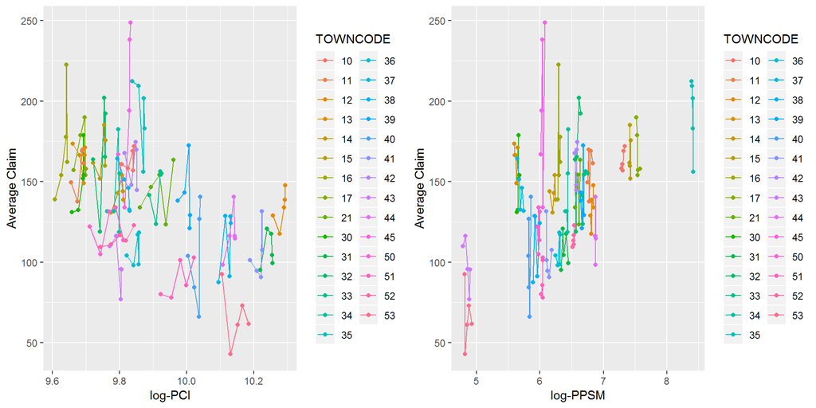

```r
train$lnPCI <- log(train$PCI)
train$lnPPSM <- log(train$PPSM)
p1 <- train %>%
  select(lnPCI, AC, TOWNCODE) %>%
  ggplot() +
  geom_line(mapping = aes(x = lnPCI, y = AC, color = TOWNCODE)) +
  geom_point(mapping = aes(x = lnPCI, y = AC, color = TOWNCODE)) +
  xlab('log-PCI') + ylab('Average Claim')
p2 <- train %>%
  select(lnPPSM, AC, TOWNCODE) %>%
  ggplot() +
  geom_line(mapping = aes(x = lnPPSM, y = AC, color = TOWNCODE)) +
  geom_point(mapping = aes(x = lnPPSM, y = AC, color = TOWNCODE)) +
  xlab('log-PPSM') + ylab('Average Claim')
grid.arrange(p1, p2, nrow = 1)
```

# 6 Linear Models

## 6.1 Simple LMs

- In this LM, all observations are considered to be independent.
- We can check the importance of each exploratory variable via **summary** and **anova**

```r
Pool.fit <- lm(formula = AC ~ lnPCI + lnPPSM + YEAR,
               data = train)
summary(Pool.fit)
```

```
##
## Call:
## lm(formula = AC ~ lnPCI + lnPPSM + YEAR, data = train)
##
## Residuals:
##     Min      1Q  Median      3Q     Max
## -49.947 -18.634  -0.876  13.480 106.342
##
## Coefficients:
##             Estimate Std. Error t value Pr(>|t|)
## (Intercept)  906.832    120.141   7.548 5.43e-12 ***
## lnPCI        -92.865     11.849  -7.837 1.11e-12 ***
## lnPPSM        22.317      2.930   7.617 3.72e-12 ***
## YEAR1994      -2.325      6.761  -0.344   0.7314
## YEAR1995      13.435      6.772   1.984   0.0493 *
## YEAR1996      10.984      6.774   1.621   0.1072
## YEAR1997      12.973      6.782   1.913   0.0578 .
## ---
## Signif. codes:  0 '***' 0.001 '**' 0.01 '*' 0.05 '.' 0.1 ' ' 1
##
## Residual standard error: 25.73 on 138 degrees of freedom
## Multiple R-squared:  0.5026, Adjusted R-squared:  0.481
## F-statistic: 23.24 on 6 and 138 DF,  p-value: < 2.2e-16
```

```r
anova(Pool.fit)
```

```
## Analysis of Variance Table
##
## Response: AC
##            Df Sum Sq Mean Sq F value    Pr(>F)
## lnPCI       1  46355   46355 70.0406 5.769e-14 ***
## lnPPSM      1  39344   39344 59.4472 2.241e-12 ***
## YEAR        4   6593    1648  2.4904   0.04603 *
## Residuals 138  91332     662
## ---
## Signif. codes:  0 '***' 0.001 '**' 0.01 '*' 0.05 '.' 0.1 ' ' 1
```

## 6.2 Fixed Effects Models

```r
FE.fit <- lm(formula = AC ~ lnPCI + lnPPSM + YEAR + TOWNCODE - 1,
               data = train)
summary(FE.fit)
```

```
##
## Call:
## lm(formula = AC ~ lnPCI + lnPPSM + YEAR + TOWNCODE - 1, data = train)
##
## Residuals:
##     Min      1Q  Median      3Q     Max
## -50.888  -9.669  -0.347   8.838  48.052
##
## Coefficients:
##            Estimate Std. Error t value Pr(>|t|)
## lnPCI        -86.87     194.24  -0.447   0.6556
## lnPPSM      -146.14     107.76  -1.356   0.1778
## YEAR1993    2073.78    2142.01   0.968   0.3351
## YEAR1994    2074.11    2146.77   0.966   0.3361
## YEAR1995    2090.96    2150.18   0.972   0.3330
## YEAR1996    2091.28    2151.27   0.972   0.3331
## YEAR1997    2096.36    2153.44   0.973   0.3324
## TOWNCODE11   -95.15      67.33  -1.413   0.1604
## TOWNCODE12   -61.98      97.56  -0.635   0.5265
## TOWNCODE13  -257.64     187.91  -1.371   0.1731
## TOWNCODE14  -184.66     119.90  -1.540   0.1264
## TOWNCODE15    12.79      22.57   0.567   0.5722
## TOWNCODE16  -156.63     119.91  -1.306   0.1942
## TOWNCODE17    26.12      37.14   0.703   0.4834
## TOWNCODE21  -115.64      77.41  -1.494   0.1381
## TOWNCODE30  -267.52     183.63  -1.457   0.1480
## TOWNCODE31  -154.99     120.96  -1.281   0.2028
## TOWNCODE32  -106.90      81.63  -1.309   0.1931
## TOWNCODE33   -98.68      66.50  -1.484   0.1407
## TOWNCODE34  -151.81      96.84  -1.568   0.1199
## TOWNCODE35   192.28     119.66   1.607   0.1109
## TOWNCODE36  -203.07     109.71  -1.851   0.0669 .
## TOWNCODE37  -255.09     174.67  -1.460   0.1470
## TOWNCODE38  -226.39     152.13  -1.488   0.1396
## TOWNCODE39  -102.05      74.03  -1.378   0.1709
## TOWNCODE40  -257.57     159.61  -1.614   0.1095
## TOWNCODE41  -197.04     139.92  -1.408   0.1619
## TOWNCODE42  -108.94      79.85  -1.364   0.1753
## TOWNCODE43  -426.72     265.96  -1.604   0.1115
## TOWNCODE44   -83.16      71.57  -1.162   0.2478
## TOWNCODE45  -153.31     137.53  -1.115   0.2674
## TOWNCODE50  -241.88     145.54  -1.662   0.0994 .
## TOWNCODE51  -246.79     136.89  -1.803   0.0742 .
## TOWNCODE52  -165.46      85.78  -1.929   0.0563 .
## TOWNCODE53  -427.59     264.18  -1.619   0.1084
## ---
## Signif. codes:  0 '***' 0.001 '**' 0.01 '*' 0.05 '.' 0.1 ' ' 1
##
## Residual standard error: 18.74 on 110 degrees of freedom
## Multiple R-squared:  0.9869, Adjusted R-squared:  0.9827
## F-statistic: 236.1 on 35 and 110 DF,  p-value: < 2.2e-16
```

```r
anova(FE.fit)
```

```
## Analysis of Variance Table
##
## Response: AC
##            Df  Sum Sq Mean Sq   F value    Pr(>F)
## lnPCI       1 2743588 2743588 7810.7776 < 2.2e-16 ***
## lnPPSM      1   63887   63887  181.8808 < 2.2e-16 ***
## YEAR        5   42471    8494   24.1824 2.386e-16 ***
## TOWNCODE   28   52694    1882    5.3577 8.362e-11 ***
## Residuals 110   38638     351
## ---
## Signif. codes:  0 '***' 0.001 '**' 0.01 '*' 0.05 '.' 0.1 ' ' 1
```

## 6.3 Model Comparison using anova function (Pool vs FE)

We will compare 2 models with partial F - test (Chow, 1960).  
Test statistics are formulated with $\mathrm{F}=\frac{(ErrorSS)_{Pooled} - ErrorSS_{FE}}{(n-1)s^2}$  
where $s^2 ( = \sqrt{\frac{38638}{110}}=18.74)$ is **the Residual Standard Error**.  
$(s.e)^2=\frac{\sum{(y_i - \hat{y})^2}}{N-(variable \; DOF)}$  
And F statistics follows an F-distribution with DOF, $df_1=28$ and $df_2=110$.  
We can compute statistics as $F=\frac{52694}{28 \times 18.74^2}=5.3577$.

```r
anova(Pool.fit, FE.fit)
```

```
## Analysis of Variance Table
##
## Model 1: AC ~ lnPCI + lnPPSM + YEAR
## Model 2: AC ~ lnPCI + lnPPSM + YEAR + TOWNCODE - 1
##   Res.Df   RSS Df Sum of Sq      F    Pr(>F)
## 1    138 91332
## 2    110 38638 28     52694 5.3577 8.362e-11 ***
## ---
## Signif. codes:  0 '***' 0.001 '**' 0.01 '*' 0.05 '.' 0.1 ' ' 1
```

# 7 Models with Serial Correlation

## 7.1 Correlation among residuals

```r
train$rPool <- resid(Pool.fit)
train %>%
  select(YEAR, TOWNCODE, rPool) %>%
  reshape(., timevar = "YEAR", idvar = "TOWNCODE", direction = "wide") %>%
  select(-TOWNCODE) %>%
  cor(.)
```

```
##            rPool.1993 rPool.1994 rPool.1995 rPool.1996 rPool.1997
## rPool.1993  1.0000000  0.5864761  0.5188005  0.4206136  0.5425032
## rPool.1994  0.5864761  1.0000000  0.3912540  0.2162662  0.2556581
## rPool.1995  0.5188005  0.3912540  1.0000000  0.3954049  0.7890627
## rPool.1996  0.4206136  0.2162662  0.3954049  1.0000000  0.4777387
## rPool.1997  0.5425032  0.2556581  0.7890627  0.4777387  1.0000000
```

## 7.2 GLS with REML

To relax i.i.d assumption, let’s consider a homogeneous model with serial correlation. For subject $i$, the matrix presentation of the model is,  
$y_i=X_i \beta+\epsilon_i$,  
where  
$y_i=(y_{i1}, \; y_{i2}, \; ... , \; y_{iT_i})^T$,  
$\epsilon_i=(\epsilon_{i1}, \; \epsilon_{i2}, \; ... , \; \epsilon_{iT_i})^T$.  
Now we assume that $\epsilon_i$ are correlated with $\mathrm{Var}({\epsilon_i})=R_i$.  
This assumption enables to relax i.i.d condition.  
Examples of $\mathrm{R}$ are following,

$$\begin{equation}
\mathrm{Compound \; Symmetry \; R} = \sigma^2
\begin{bmatrix}
1 &\rho &\rho \\
\rho &1 &\rho \\
\rho &\rho &1
\end{bmatrix}
\end{equation}$$

$$\begin{equation}
\mathrm{AR(1) \; R} = \sigma^2
\begin{bmatrix}
1 &\rho &\rho^2 \\
\rho &1 &\rho \\
\rho^2 &\rho &1
\end{bmatrix}
\end{equation}$$

$$\begin{equation}
\mathrm{Unstructured \; R} =
\begin{bmatrix}
\sigma^2 &\sigma_{12} &\sigma_{13} \\
\sigma_{12} &\sigma^2 &\sigma_{23} \\
\sigma_{13} &\sigma_{23} &\sigma^2
\end{bmatrix}
\end{equation}$$

Generalized Least Squares (GLS) estimates are obtained by minimizing,  
$\sum^{n}_{i-1}(y_i-X_i\beta)^T \; R_i^{-1} (y_i-X_i\beta)$.  
library `nlme` provides 2 types of likelihood-based methods,

- Maximum Likelihood
- REstricted Maximum Likelihood

REML is used to fix downward biased correlation $\mathrm{R}$.  
We will use here `gls()` function to model above 3 types of $\mathrm{R}$.  
The gls function estimates the model under the parameterization $\mathrm{R} = \sigma^2 \Sigma$, where $\sigma^2$ is a scale parameter and $\Sigma$ is the correlation matrix.

### 7.2.1 Compound Symmetry

```r
# Serial Correlation => SC
SCex.fit <- gls(AC ~ lnPCI + lnPPSM + YEAR,
                data = train,
                correlation = corCompSymm(form = ~ 1 | TOWNCODE))
summary(SCex.fit)
```

```
## Generalized least squares fit by REML
##   Model: AC ~ lnPCI + lnPPSM + YEAR
##   Data: train
##        AIC      BIC    logLik
##   1286.887 1313.233 -634.4437
##
## Correlation Structure: Compound symmetry
##  Formula: ~1 | TOWNCODE
##  Parameter estimate(s):
##       Rho
## 0.4817291
##
## Coefficients:
##                Value Std.Error   t-value p-value
## (Intercept) 906.1706 207.41999  4.368772  0.0000
## lnPCI       -92.6033  20.46490 -4.524983  0.0000
## lnPPSM       22.0143   5.07870  4.334628  0.0000
## YEAR1994     -2.3260   4.95400 -0.469526  0.6394
## YEAR1995     13.4322   4.99858  2.687193  0.0081
## YEAR1996     10.9852   5.00720  2.193880  0.0299
## YEAR1997     12.9788   5.03888  2.575738  0.0111
##
##  Correlation:
##          (Intr) lnPCI  lnPPSM YEAR1994 YEAR1995 YEAR1996
## lnPCI    -0.988
## lnPPSM   -0.248  0.095
## YEAR1994  0.081 -0.091 -0.026
## YEAR1995  0.150 -0.160 -0.039  0.506
## YEAR1996  0.160 -0.167 -0.056  0.506    0.514
## YEAR1997  0.191 -0.196 -0.077  0.506    0.516    0.517
##
## Standardized residuals:
##         Min          Q1         Med          Q3         Max
## -1.92213513 -0.71201932 -0.02800883  0.52036234  4.07269162
##
## Residual standard error: 26.09092
## Degrees of freedom: 145 total; 138 residual
```

```r
intervals(SCex.fit, which = "var-cov")
```

```
## Approximate 95% confidence intervals
##
##  Correlation structure:
##         lower      est.     upper
## Rho 0.2956104 0.4817291 0.6501988
## attr(,"label")
## [1] "Correlation structure:"
##
##  Residual standard error:
##    lower     est.    upper
## 22.06354 26.09092 30.85343
```

```r
getVarCov(SCex.fit)
```

```
## Marginal variance covariance matrix
##        [,1]   [,2]   [,3]   [,4]   [,5]
## [1,] 680.74 327.93 327.93 327.93 327.93
## [2,] 327.93 680.74 327.93 327.93 327.93
## [3,] 327.93 327.93 680.74 327.93 327.93
## [4,] 327.93 327.93 327.93 680.74 327.93
## [5,] 327.93 327.93 327.93 327.93 680.74
##   Standard Deviations: 26.091 26.091 26.091 26.091 26.091
```

### 7.2.2 AR(1)

```r
SCar.fit <- gls(AC ~ lnPCI + lnPPSM + YEAR,
                data = train,
                correlation = corAR1(form = ~ 1 | TOWNCODE))
summary(SCar.fit)
```

```
## Generalized least squares fit by REML
##   Model: AC ~ lnPCI + lnPPSM + YEAR
##   Data: train
##        AIC      BIC    logLik
##   1302.791 1329.137 -642.3956
##
## Correlation Structure: AR(1)
##  Formula: ~1 | TOWNCODE
##  Parameter estimate(s):
##       Phi
## 0.4523347
##
## Coefficients:
##                Value Std.Error   t-value p-value
## (Intercept) 901.1347 170.09788  5.297742  0.0000
## lnPCI       -91.9345  16.78287 -5.477880  0.0000
## lnPPSM       21.7691   4.15156  5.243592  0.0000
## YEAR1994     -2.3365   5.03429 -0.464109  0.6433
## YEAR1995     13.4122   6.08624  2.203688  0.0292
## YEAR1996     10.9683   6.50052  1.687301  0.0938
## YEAR1997     12.9620   6.69351  1.936497  0.0549
##
##  Correlation:
##          (Intr) lnPCI  lnPPSM YEAR1994 YEAR1995 YEAR1996
## lnPCI    -0.988
## lnPPSM   -0.248  0.095
## YEAR1994  0.060 -0.074 -0.021
## YEAR1995  0.091 -0.108 -0.026  0.605
## YEAR1996  0.089 -0.105 -0.035  0.472    0.684
## YEAR1997  0.105 -0.121 -0.048  0.418    0.555    0.711
##
## Standardized residuals:
##         Min          Q1         Med          Q3         Max
## -1.95024157 -0.71932633 -0.03872738  0.53108331  4.11236714
##
## Residual standard error: 25.83138
## Degrees of freedom: 145 total; 138 residual
```

```r
intervals(SCar.fit, which = "var-cov")
```

```
## Approximate 95% confidence intervals
##
##  Correlation structure:
##         lower      est.     upper
## Phi 0.2817169 0.4523347 0.5952237
## attr(,"label")
## [1] "Correlation structure:"
##
##  Residual standard error:
##    lower     est.    upper
## 22.46799 25.83138 29.69825
```

```r
getVarCov(SCar.fit)
```

```
## Marginal variance covariance matrix
##         [,1]    [,2]   [,3]    [,4]    [,5]
## [1,] 667.260 301.820 136.53  61.755  27.934
## [2,] 301.820 667.260 301.82 136.530  61.755
## [3,] 136.530 301.820 667.26 301.820 136.530
## [4,]  61.755 136.530 301.82 667.260 301.820
## [5,]  27.934  61.755 136.53 301.820 667.260
##   Standard Deviations: 25.831 25.831 25.831 25.831 25.831
```

### 7.2.3 Unstructured

```r
SCun.fit <- gls(AC ~ lnPCI + lnPPSM + YEAR,
                data = train,
                correlation = corSymm(form = ~ 1 | TOWNCODE))
summary(SCun.fit)
```

```
## Generalized least squares fit by REML
##   Model: AC ~ lnPCI + lnPPSM + YEAR
##   Data: train
##        AIC      BIC    logLik
##   1284.064 1336.754 -624.0319
##
## Correlation Structure: General
##  Formula: ~1 | TOWNCODE
##  Parameter estimate(s):
##  Correlation:
##   1     2     3     4
## 2 0.687
## 3 0.502 0.399
## 4 0.452 0.273 0.388
## 5 0.537 0.278 0.750 0.482
##
## Coefficients:
##                Value Std.Error   t-value p-value
## (Intercept) 896.5966 200.02039  4.482526  0.0000
## lnPCI       -92.7681  19.72627 -4.702771  0.0000
## lnPPSM       23.7768   4.91569  4.836909  0.0000
## YEAR1994     -2.3517   3.84262 -0.611992  0.5415
## YEAR1995     13.3969   4.87498  2.748083  0.0068
## YEAR1996     10.9210   5.11661  2.134432  0.0346
## YEAR1997     12.8831   4.74418  2.715565  0.0075
##
##  Correlation:
##          (Intr) lnPCI  lnPPSM YEAR1994 YEAR1995 YEAR1996
## lnPCI    -0.988
## lnPPSM   -0.251  0.097
## YEAR1994  0.106 -0.113 -0.032
## YEAR1995  0.148 -0.158 -0.039  0.280
## YEAR1996  0.149 -0.158 -0.053  0.178    0.431
## YEAR1997  0.196 -0.200 -0.080  0.092    0.747    0.506
##
## Standardized residuals:
##         Min          Q1         Med          Q3         Max
## -1.89256083 -0.71188290 -0.03204557  0.54669422  4.11388207
##
## Residual standard error: 25.96999
## Degrees of freedom: 145 total; 138 residual
```

```r
intervals(SCun.fit, which = "var-cov")
```

```
## Approximate 95% confidence intervals
##
##  Correlation structure:
##                lower      est.     upper
## cor(1,2)  0.43560196 0.6867604 0.8387097
## cor(1,3)  0.20374780 0.5021413 0.7151718
## cor(1,4)  0.07534260 0.4519698 0.7157425
## cor(1,5)  0.20578615 0.5372994 0.7581862
## cor(2,3)  0.08247888 0.3992104 0.6426950
## cor(2,4) -0.14003629 0.2732765 0.6054870
## cor(2,5) -0.11148910 0.2776431 0.5929526
## cor(3,4)  0.09234631 0.3882658 0.6211668
## cor(3,5)  0.57370053 0.7495511 0.8593458
## cor(4,5)  0.17595443 0.4823999 0.7036077
## attr(,"label")
## [1] "Correlation structure:"
##
##  Residual standard error:
##    lower     est.    upper
## 21.97111 25.96999 30.69669
```

```r
getVarCov(SCun.fit)
```

```
## Marginal variance covariance matrix
##        [,1]   [,2]   [,3]   [,4]   [,5]
## [1,] 674.44 463.18 338.66 304.83 362.38
## [2,] 463.18 674.44 269.24 184.31 187.25
## [3,] 338.66 269.24 674.44 261.86 505.53
## [4,] 304.83 184.31 261.86 674.44 325.35
## [5,] 362.38 187.25 505.53 325.35 674.44
##   Standard Deviations: 25.97 25.97 25.97 25.97 25.97
```